# Analysis of absenteeism at work

Clarison James Dsilva

### INTRODUCTION

Absenteeism in the workplace is a common phenomenon. Absenteeism, also referred to as a “bottom-line killer”, impacts the availability of the workforce and the profitability of organizations. The high competitiveness in the market, professional development combined with the development of organizations and the pressure to reach increasingly audacious goals, create increasingly overburdened employees and end up acquiring some disturbance in the state of health related to the type of work activity, including depression considered the evil of the 21st century. Taking employees to absenteeism. Absenteeism is defined as absence to work as expected, represents for the company the loss of productivity and quality of work.

The data set has been taken from UCI - Absenteeism at work. The database used has 21 attributes and 740 records from documents that prove that they are absent from work and was collected from January 2008 to December 2016 at a courier company in Brazil.

### PROBLEM STATEMENT

To determine how various factors are affecting the absenteeism at work and plot different graphs to analyse the same.

```r
#install.packages(scales)
#install.packages(readxl)
#install.packages(gridExtra)
#install.packages(plyr)

library(dplyr)
```

```r
library(readxl)
library(ggplot2)
library(tidyverse)
library(tidyr)
library(scales)
library(gridExtra)
library(plyr)
library(stringr)
```

```r
absent <- read_excel("Absenteeism_at_work.xls")

reason <- read_excel("Absenteeism_at_work.xls","Reason for Absense")

seasons <- read_excel("Absenteeism_at_work.xls","Seasons")

dayofweek <- read_excel("Absenteeism_at_work.xls","Day of Week")

education <- read_excel("Absenteeism_at_work.xls","Education")

month <- read_excel("Absenteeism_at_work.xls","Month")

finaldf <- left_join(absent,reason, by = c("Reason for absence"="Reason for Absense ID")) %>%
  left_join(seasons, by = c("Seasons"="Season ID")) %>%
  left_join(dayofweek, by = c("Day of the week"="Day of Week ID"))  %>%
  left_join(education, by = c("Education"="Education ID")) %>%
  left_join(month, by = c("Month of absence"="Month ID"))

finaldf
```

```
## # A tibble: 740 x 26
##       ID `Reason for absence` `Month of absence` `Day of the week` Seasons
##    <dbl>                <dbl>              <dbl>             <dbl>   <dbl>
##  1    11                   26                  7                 3       1
##  2    36                    0                  7                 3       1
##  3     3                   23                  7                 4       1
##  4     7                    7                  7                 5       1
##  5    11                   23                  7                 5       1
##  6     3                   23                  7                 6       1
##  7    10                   22                  7                 6       1
##  8    20                   23                  7                 6       1
##  9    14                   19                  7                 2       1
## 10     1                   22                  7                 2       1
## # ... with 730 more rows, and 21 more variables: Transportation expense <dbl>,
## #   Distance from Residence to Work <dbl>, Service time <dbl>, Age <dbl>,
## #   Work load Average/day <dbl>, Hit target <dbl>, Disciplinary failure <dbl>,
## #   Education <dbl>, Son <dbl>, Social drinker <dbl>, Social smoker <dbl>,
## #   Pet <dbl>, Weight <dbl>, Height <dbl>, Body mass index <dbl>,
## #   Absenteeism time in hours <dbl>, Absense Reason <chr>,
## #   Season Details <chr>, Day of Week Name <chr>, Education Details <chr>, ...
```

```r
##### **Code Output :**
# Separate columns are created to define the numerical categories as characters and are stored in finaldf.
```

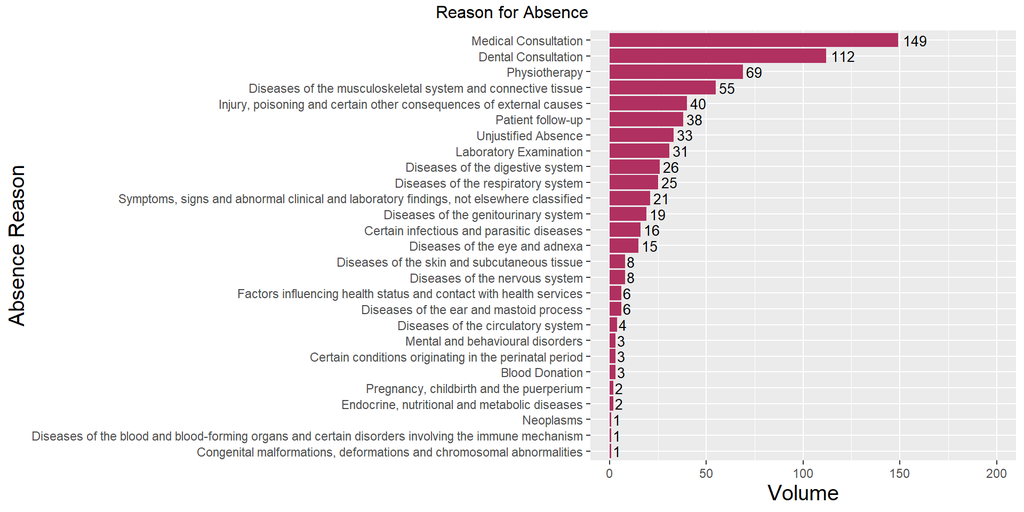

```r
# ##### **Visual Analysis :**
# This Visual represents number of absentees by Absence Reasons. Data is grouped by absence reason and a horizontal bar graph is plot between reason of absence and number of absentees (Volume).

by_reason <- finaldf %>%
  group_by(`Absense Reason`)  %>%
  dplyr :: summarise(count = n()) %>%
  drop_na()

plot_absent <- ggplot(by_reason ,aes(x = reorder(`Absense Reason`,count),y = count)) + geom_bar(stat = "identity", fill= 'maroon') + coord_flip() +
  ylim(0,200) +
  geom_text(aes(label = count), hjust = -0.2,size=3.5) +
  labs(x = "Absence Reason",y = "Volume") +
  theme(axis.title.x = element_text(size=15),axis.title.y = element_text(size = 15))

grid.arrange(plot_absent,top = "Reason for Absence")
```

```r
# ##### **Insights :**
# From the plot, we can see that the major reasons for absenteeism are Medical, Dental consultation, Physiotherapy. Most of the reasons for absentees are disease of some kind.
```

```r
# ##### **Visual Analysis :**
# This Visual represents  absenteeism trend with respect to month.


by_month <- finaldf %>%
  group_by(Month,`Month of absence`)  %>%
  dplyr:: summarise(count = n())  %>%
  drop_na()
```

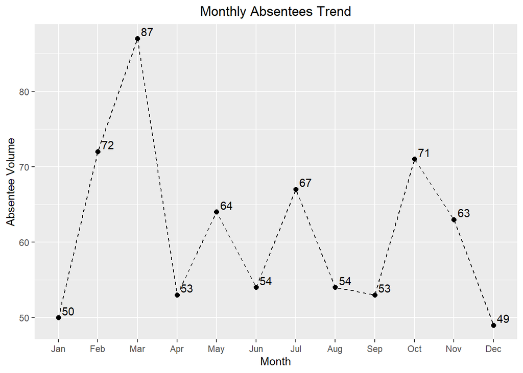

```r
ggplot(by_month,aes(x = reorder(`Month`, `Month of absence`), y = count, group = 1)) +
  geom_line(linetype = "dashed") +
  ggtitle("Monthly Absentees Trend") +
  labs(x="Month", y="Absentee Volume") +
  geom_point(size = 2) +
  geom_text(aes(label = count), vjust = -0.3, hjust = -0.3) +
  theme(plot.title = element_text(hjust = 0.5))
```